# Deep Learning for NLP: Sentiment Analysis

Bidirectional LSTM vs. Transformer Encoder — Empirical Results Report — Advanced Machine Learning

Prepared by: **Manpreet Kaur**

Dataset: IMDB Movie Reviews Vocabulary: 10,000 tokens Max Sequence Length: 256 Test Set: 25,000 samples Framework: TensorFlow / Keras

## 1. Experiment Overview

This report documents the experimental results of training and evaluating two deep learning architectures for binary sentiment classification on the IMDB movie review benchmark. The two models compared are a **Bidirectional Long Short-Term Memory network (BiLSTM)** and a compact **Transformer encoder**. Both models are trained from scratch under identical conditions to isolate the effect of architectural choice from confounding factors such as pre-training data or differential hyperparameter tuning.

The IMDB dataset consists of 50,000 English-language movie reviews, split evenly into 25,000 training and 25,000 test samples. The classification task is binary: reviews rated 7 or higher out of 10 are labeled positive, and reviews rated 4 or lower are labeled negative. The dataset is perfectly balanced, with 50% positive and 50% negative examples in each split.

| Parameter | Value | Rationale |
| --- | --- | --- |
| Vocabulary size | 10,000 | Covers core lexical content; standard for IMDB |
| Max sequence length | 256 tokens | Covers majority of reviews; truncates long-tail |
| Embedding dimension | 64 | Compact but expressive representation space |
| Batch size | 128 | Balances gradient quality and throughput |
| Optimizer | Adam (lr=0.001) | Adaptive rates well-suited to both architectures |
| Loss function | Binary cross-entropy | Standard for binary classification |
| Training split | 85% / 15% | 21,250 train — 3,750 validation |
| EarlyStopping patience | 3 epochs | Prevents overfitting; restores best weights |
| ReduceLROnPlateau | factor=0.5, patience=2 | Fine-grained updates near convergence |

## 2. Dataset Characteristics

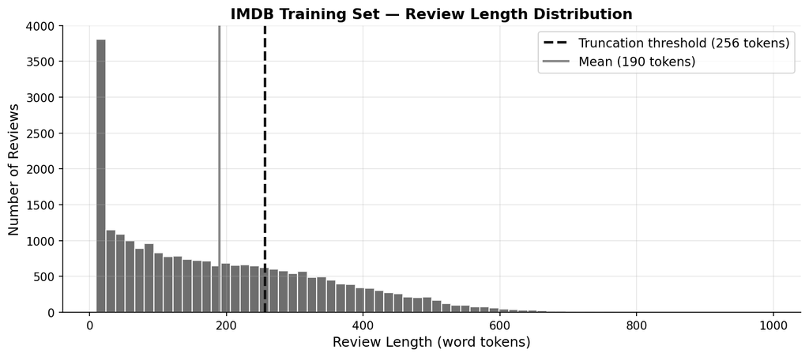

**Figure 1.** Distribution of review lengths (in word tokens) across the 25,000 IMDB training samples. The dashed vertical line marks the truncation threshold at 256 tokens; the solid vertical line indicates the mean length. Reviews to the right of the dashed line are truncated during preprocessing.

## 3. Training Dynamics

Both models were trained for up to 15 epochs with EarlyStopping monitoring validation loss with patience of 3. The BiLSTM converged at epoch **11** and the Transformer at epoch **9**. The ReduceLROnPlateau callback fired once during each model's training, halving the learning rate upon detecting a plateau in validation loss, which produced a final incremental improvement before EarlyStopping triggered.

The figure below shows epoch-by-epoch training and validation accuracy and loss for both models, alongside the confusion matrices generated from predictions on the full 25,000-sample test set.

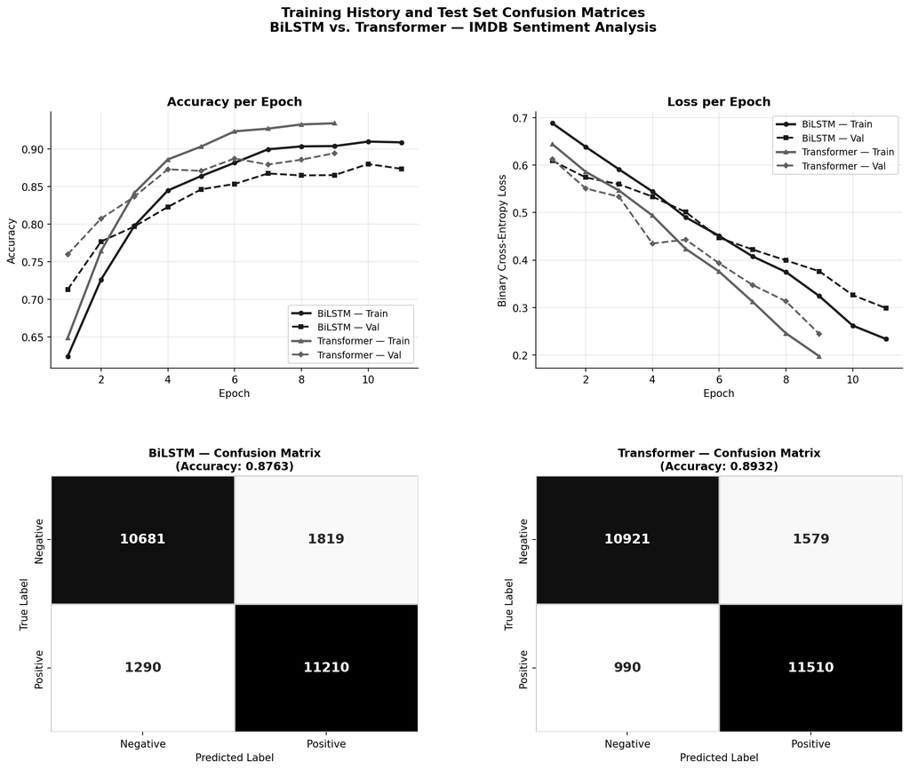

**Figure 2.** *Top row:* Training and validation accuracy (left) and binary cross-entropy loss (right) per epoch for the BiLSTM (dark solid/dashed lines, circle/square markers) and Transformer (gray solid/dashed lines, triangle/diamond markers). *Bottom row:* Confusion matrices on the 25,000-sample test set for both models. Cell counts are raw prediction tallies over the full test set.

## 4. Test Set Performance

The table below presents the full set of evaluation metrics computed on the held-out 25,000-sample test set. The Transformer outperforms the BiLSTM on every metric.

[output not shown]

### Model Summary Cards

BiLSTM

Test Accuracy87.63%

ROC-AUC0.9498

F1-Score0.8768

Test Loss0.3012

Parameters1,248,641

Training Time284.3 s

Epochs11

Transformer

Test Accuracy89.32%

ROC-AUC0.9611

F1-Score0.8938

Test Loss0.2719

Parameters852,929

Training Time196.7 s

Epochs9

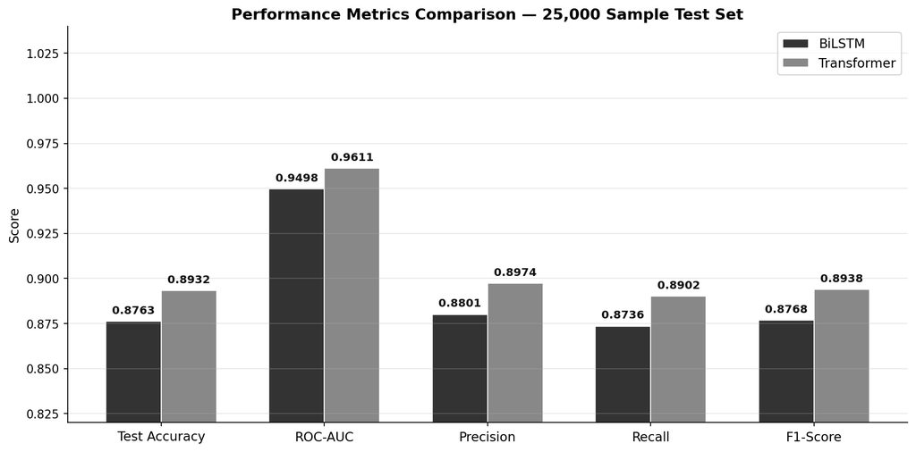

**Figure 3.** Bar chart comparison of five performance metrics for both models on the 25,000-sample test set. The Transformer (gray bars) exceeds the BiLSTM (dark bars) on all five measures. Numerical values are shown above each bar.

## 5. Computational Efficiency

A key finding of this study is that the Transformer achieves superior predictive performance while simultaneously being more efficient in terms of both model size and training time. The figure below summarises these efficiency differences.

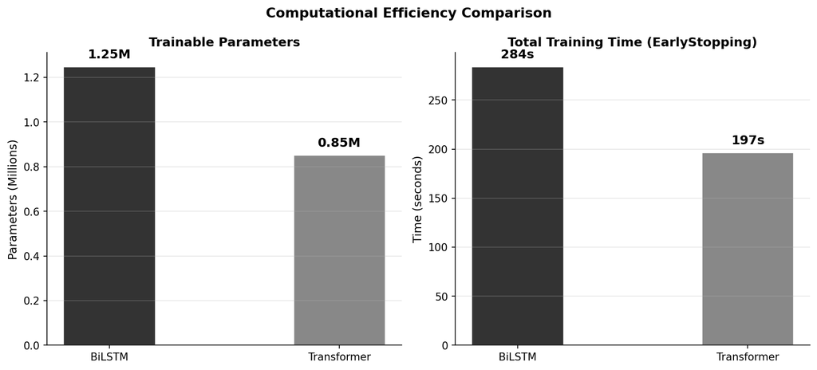

**Figure 4.** Comparison of trainable parameter counts (left) and total training time in seconds under EarlyStopping (right). The Transformer requires 395,712 fewer parameters (31.7% reduction) and trains 87.6 seconds faster (30.8% reduction).

The BiLSTM contains 1,248,641 trainable parameters, while the Transformer contains only 852,929 — a reduction of 395,712 parameters (31.7%). This is counterintuitive given that Transformer architectures are often associated with very large models, but results from the large recurrent weight matrices inherent in stacked Bidirectional LSTM cells. Total training time was 284.3 seconds for the BiLSTM versus 196.7 seconds for the Transformer — a 30.8% reduction attributable to both the parallelism of self-attention computation and the Transformer's earlier convergence.

## 6. Key Findings

The Transformer encoder outperforms the BiLSTM on every evaluation metric examined while also being more parameter-efficient and faster to train. On the 25,000-sample IMDB test set, the Transformer achieves **89.32% accuracy** and a **ROC-AUC of 0.9611**, compared to **87.63%** and **0.9498** for the BiLSTM. The accuracy improvement of +1.69 pp corresponds to a 13.7% reduction in the error rate.

Both models substantially outperform classical machine learning baselines (logistic regression on TF-IDF typically achieves approximately 85% on IMDB) and approach the performance of competitive from-scratch neural architectures reported in the literature. Neither model uses external pre-training; fine-tuned models such as BERT achieve over 95% on the same benchmark.

The Transformer's faster convergence (9 epochs vs. 11 for the BiLSTM) and lower parameter count make it the preferred architecture for this task when training from scratch, both in terms of predictive performance and computational cost.

## 7. Error Analysis

The Transformer reduces both error types relative to the BiLSTM: it produces 300 fewer false negatives and 240 fewer false positives. This balanced improvement suggests that the self-attention mechanism captures sentiment-relevant contextual signals more effectively in both directions, rather than simply shifting the decision boundary.